# Air Quality Category Tables

Processed on 2024-03-04 13:14:18 PST.

*Disclaimer: Data presented here come from a variety of sources and do not represent official EPA measurements. Please visit [AirNow](https://www.airnow.gov) for official measurements.*

Cumulative exposure to smoke is an important public health metric. This report summarizes the cumulative number of days air quality monitors in Kentucky spent in each AQI category during the the month of September.

The tables below include only permanent monitors measuring PM<sub>2.5</sub> and show cumulative exposure under existing NAAQS (National Ambient Air Quality Standards) and under the [2024 revised standards for PM2.5](https://www.epa.gov/pm-pollution/final-reconsideration-national-ambient-air-quality-standards-particulate-matter-pm).

In the tables and plots below, ‘Old’ designates cumulative days calculated using the 2023 PM<sub>2.5</sub> NAAQS while ‘New’ is calculated using the 2024 revised PM<sub>2.5</sub> NAAQS. The impact of the NAAQS revision is quite clear.

## September in Kentucky

|  | Good | Moderate | USG | Unhealthy | Very Unhealthy | Hazardous | Missing |
| --- | --- | --- | --- | --- | --- | --- | --- |
| Old | 127 | 20 | 0 | 0 | 0 | 0 | 8 |
| New | 93 | 54 | 0 | 0 | 0 | 0 | 8 |

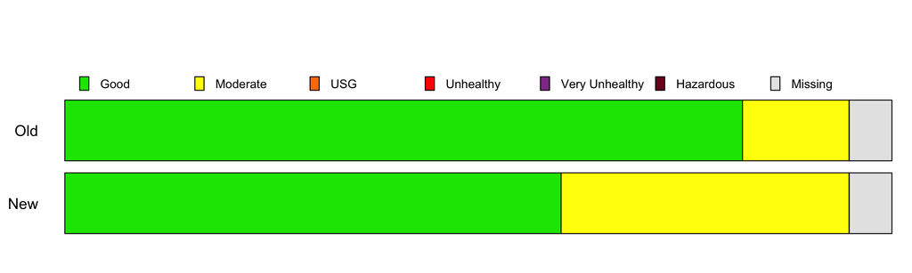

### September 2015 – 6 permanent monitors

|  | Good | Moderate | USG | Unhealthy | Very Unhealthy | Hazardous | Missing |
| --- | --- | --- | --- | --- | --- | --- | --- |
| Old | 130 | 50 | 0 | 0 | 0 | 0 | 6 |
| New | 91 | 89 | 0 | 0 | 0 | 0 | 6 |

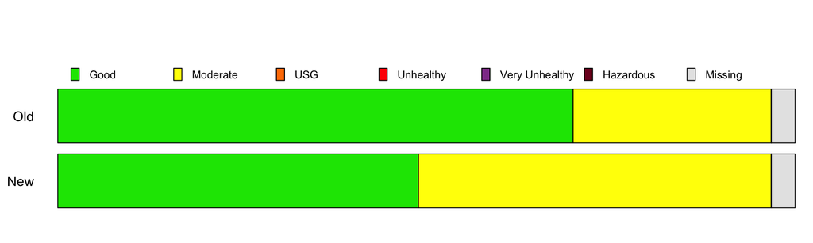

### September 2016 – 12 permanent monitors

`Processing error: Unable to calculate tables.`

### September 2017 – 6 permanent monitors

|  | Good | Moderate | USG | Unhealthy | Very Unhealthy | Hazardous | Missing |
| --- | --- | --- | --- | --- | --- | --- | --- |
| Old | 134 | 45 | 0 | 0 | 0 | 0 | 7 |
| New | 88 | 91 | 0 | 0 | 0 | 0 | 7 |

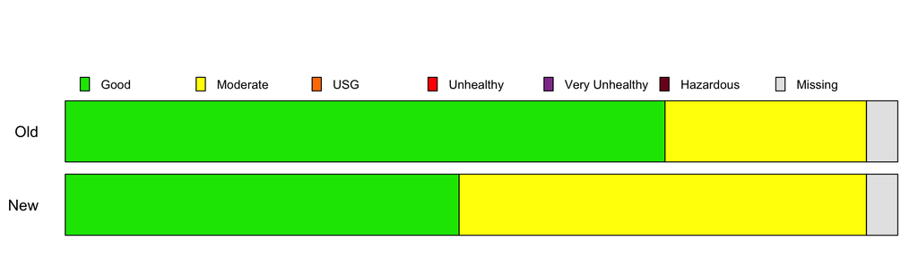

### September 2018 – 12 permanent monitors

`Processing error: Unable to calculate tables.`

### September 2019 – 6 permanent monitors

|  | Good | Moderate | USG | Unhealthy | Very Unhealthy | Hazardous | Missing |
| --- | --- | --- | --- | --- | --- | --- | --- |
| Old | 149 | 28 | 0 | 0 | 0 | 0 | 9 |
| New | 102 | 75 | 0 | 0 | 0 | 0 | 9 |

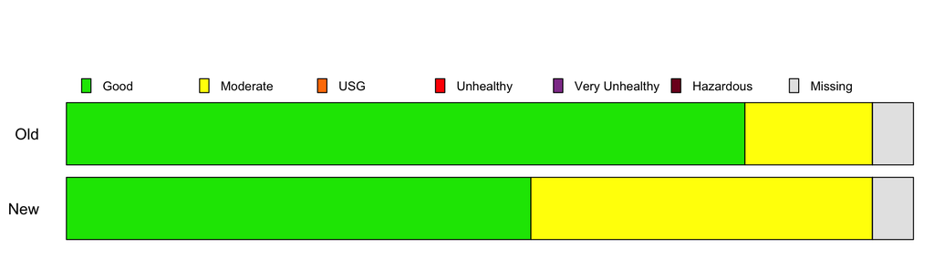

### September 2020 – 12 permanent monitors

`Processing error: Unable to calculate tables.`

### September 2021 – 8 permanent monitors

|  | Good | Moderate | USG | Unhealthy | Very Unhealthy | Hazardous | Missing |
| --- | --- | --- | --- | --- | --- | --- | --- |
| Old | 214 | 25 | 0 | 0 | 0 | 0 | 9 |
| New | 179 | 60 | 0 | 0 | 0 | 0 | 9 |

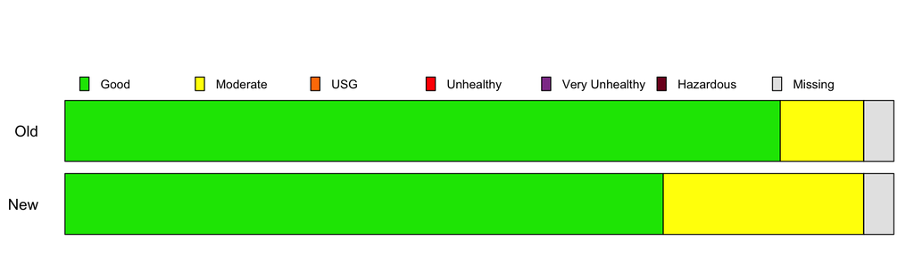

### September 2022 – 9 permanent monitors

|  | Good | Moderate | USG | Unhealthy | Very Unhealthy | Hazardous | Missing |
| --- | --- | --- | --- | --- | --- | --- | --- |
| Old | 257 | 13 | 0 | 0 | 0 | 0 | 9 |
| New | 220 | 50 | 0 | 0 | 0 | 0 | 9 |

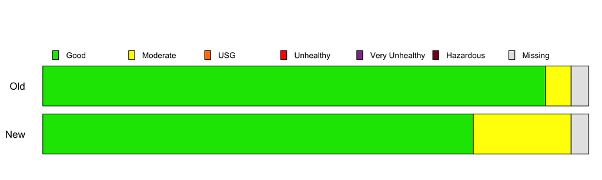

### September 2023 – 9 permanent monitors

|  | Good | Moderate | USG | Unhealthy | Very Unhealthy | Hazardous | Missing |
| --- | --- | --- | --- | --- | --- | --- | --- |
| Old | 254 | 9 | 0 | 0 | 0 | 0 | 16 |
| New | 205 | 58 | 0 | 0 | 0 | 0 | 16 |

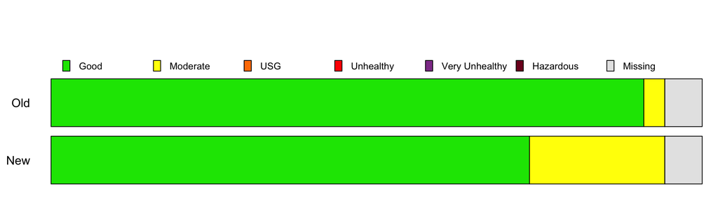